# Create Pelagic Low Bycatch Layer for the Bering Strait Region

Jamie Afflerbach

9/24/2015

```r
invisible(source('../../common.R'))
# Libraries

library(tidyr)
library(reshape2)
library(rgeos)
```

On the US side of the BSR, catch data for our region for the years 2009-2013 comes from the Alaska Commercial Fisheries Entry (CFEC). All salmon fishing in our region uses set gillnet and has low bycatch and can therefore be categorized as pelagic, low bycatch fishing.

**Read in AK fisheries data**

```r
raw = read.csv('raw/BIT.csv',stringsAsFactors=F)
```

**Filter data to select three towns in our region, Kotzebue, Norton Sound and Lower Yukon and for all years 2009-2013.

```r
#locations in our BSR region. Filter raw dataset to select just these locations

bsr_towns = c("KOTZEBUE","NORTON SOUND","LOWER YUKON")

data = raw%>%
        filter(Year>2008,Total.Pounds>0)%>% #select all years 2009-2013
         select(Fishery, Fishery.Description,Year, Total.Pounds)%>%
          separate(Fishery.Description,c("Species","Gear","Location"),", ",extra='merge')

data$Total.Pounds = as.numeric(gsub(',','',data$Total.Pounds))

salmon = data%>%
          filter(Species=='SALMON',
                 Location %in% bsr_towns)%>%
            group_by(Location)%>%
             summarise(avg_catch = mean(Total.Pounds)*0.000453592)%>% #pounds to tons
              as.data.frame()

print(salmon)
```

```
##       Location avg_catch
## 1     KOTZEBUE  918.8083
## 2  LOWER YUKON 1290.9358
## 3 NORTON SOUND  542.2512
```

Based on [this description](http://www.cfec.state.ak.us/bit/MNUSALM.htm) and the fishing codes found [here](http://www.cfec.state.ak.us/spcs/MENUS.htm), the fishing gear used are set gillnets, not drift

**Bring in shapefiles for each of the 3 management areas**

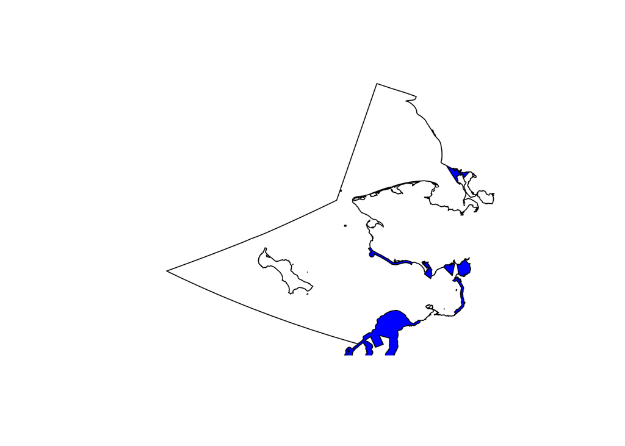

```r
us_eez <- readOGR(dsn=file.path(dir_arctic,'gis/bsr'),layer='USA_EEZ',verbose=F)


salm <- readOGR(dsn=file.path(dir_arctic,'stressors/commercial_fisheries/gis'),layer='BSR_AK_salmon_areas',verbose=F)
salm <- spTransform(salm,laeaCRS)
plot(us_eez)
plot(salm,add=T,col='blue')
```

Get number of cells in each polygon so we can calculate catch per cell

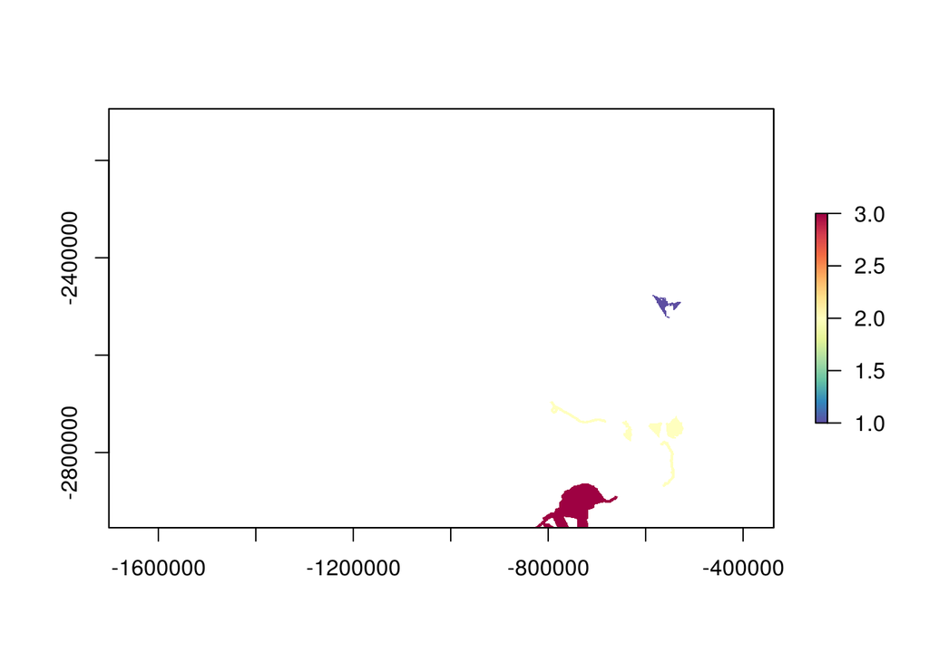

```r
salm@data$location = c('KOTZEBUE','NORTON SOUND','LOWER YUKON')
salm@data$catch = salmon$avg_catch[match(salm@data$location,salmon$Location)]

salm_zones = rasterize(salm,bsr_ocean)
plot(salm_zones,col=cols) #r automatically assigns values to each region. Kotzebue = 1, Norton Sound = 2 and Lower Yukon = 3
```

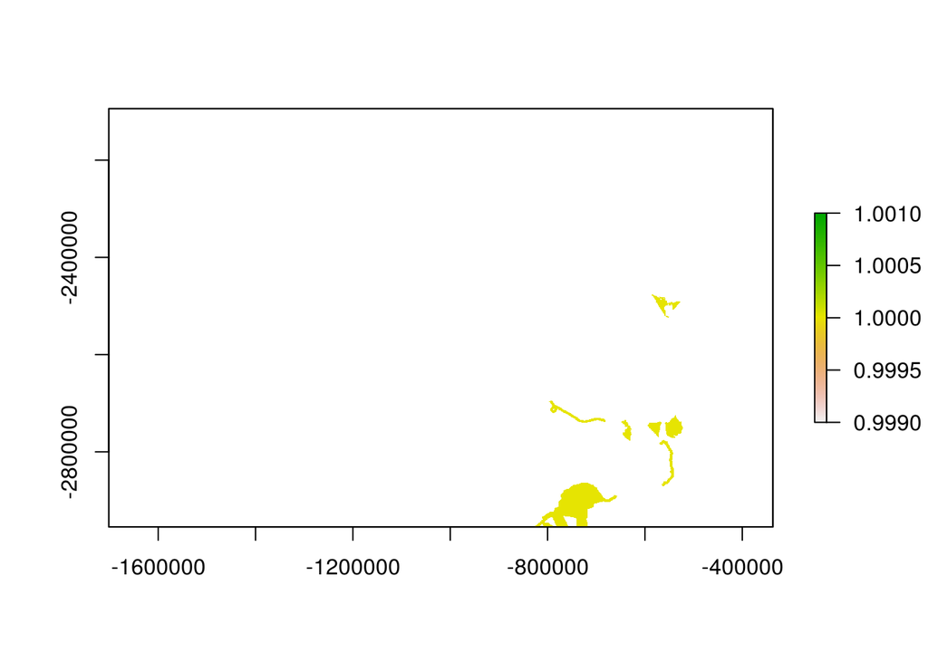

```r
salm_ras = rasterize(salm,bsr_ocean,1)
plot(salm_ras)
```

```r
# to get total area for each, run zonal

z = zonal(salm_ras,salm_zones,sum)
z
```

```
##      zone value
## [1,]    1   857
## [2,]    2  4078
## [3,]    3  7564
```

```r
salm@data$n_cells = c(857, 4078, 7564)
salm@data$catch_per_cell = salm@data$catch/salm@data$n_cells

print(salm@data)
```

```
##   Id       Area     location     catch n_cells catch_per_cell
## 0  0   745.6836     KOTZEBUE  918.8083     857      1.0721217
## 1  0  3560.0293 NORTON SOUND  542.2512    4078      0.1329699
## 2  0 17752.0466  LOWER YUKON 1290.9358    7564      0.1706684
```

Bring in the russian catch raster for pelagic low bycatch

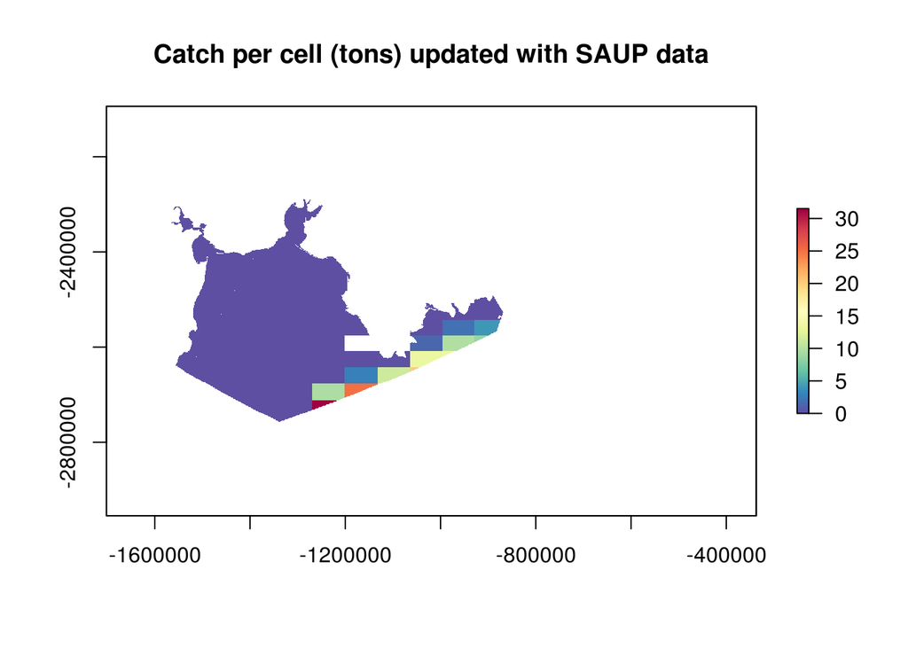

```r
  pel_lb_rus = raster('working/pel_lb_rus_catch.tif')
  plot(pel_lb_rus,col=cols,main='Catch per cell (tons) updated with SAUP data')
```

Then replace values within US waters with catch per cell calculated for salmon

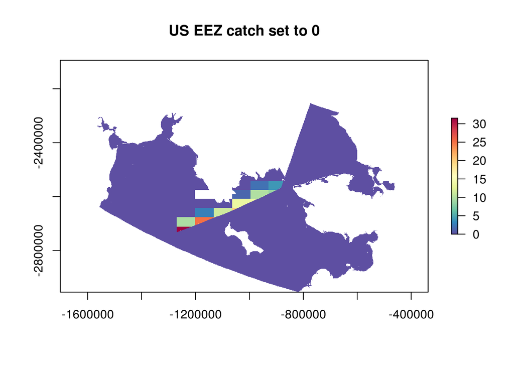

```r
# first turn all US EEZ values to 0, this will help keep 0 where there isn't fishing

    pel_lb_US = rasterize(us_eez,pel_lb_rus,0,update=TRUE)
    plot(pel_lb_US,col=cols, main='US EEZ catch set to 0')
```

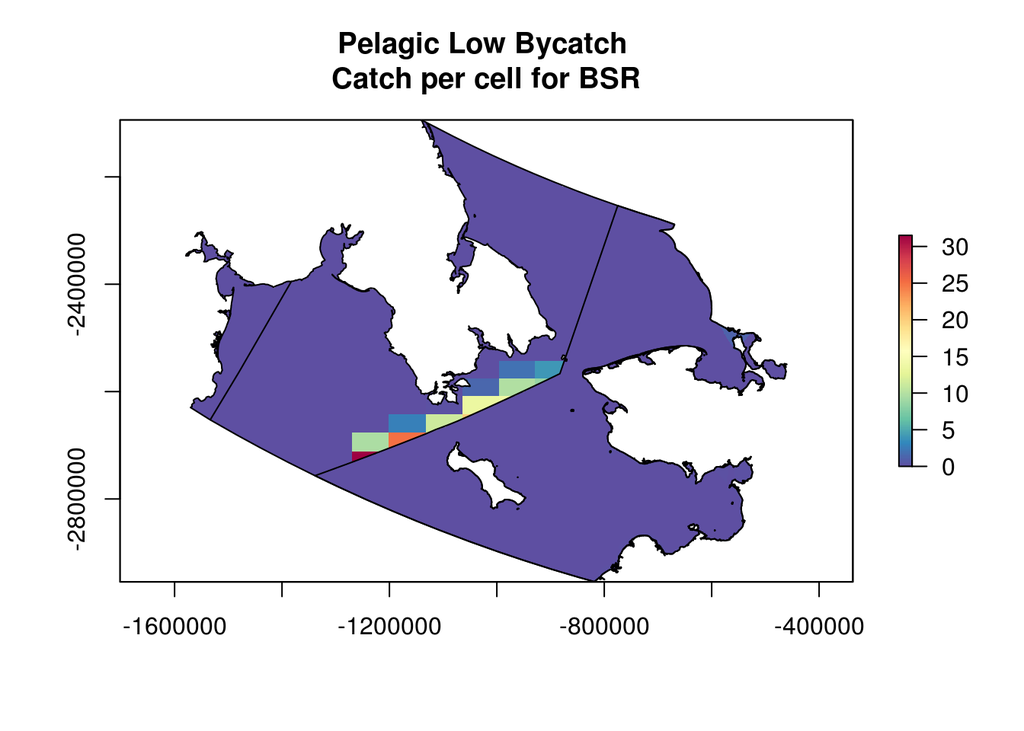

```r
# now update the salmon fishing area with catch rate per km2
    pel_lb_bsr = rasterize(salm,pel_lb_US,field=salm@data$catch_per_cell,update=TRUE,
                            filename='working/pel_lb_catch.tif',overwrite=T)

    pel_lb_bsr[is.na(pel_lb_bsr)]<-0

    pel_lb_bsr = mask(pel_lb_bsr,bsr)

    plot(pel_lb_bsr,col=cols,main='Pelagic Low Bycatch \nCatch per cell for BSR')
    plot(bsr,add=T)
    plot(us_eez,add=T)
```

Bring in productivity

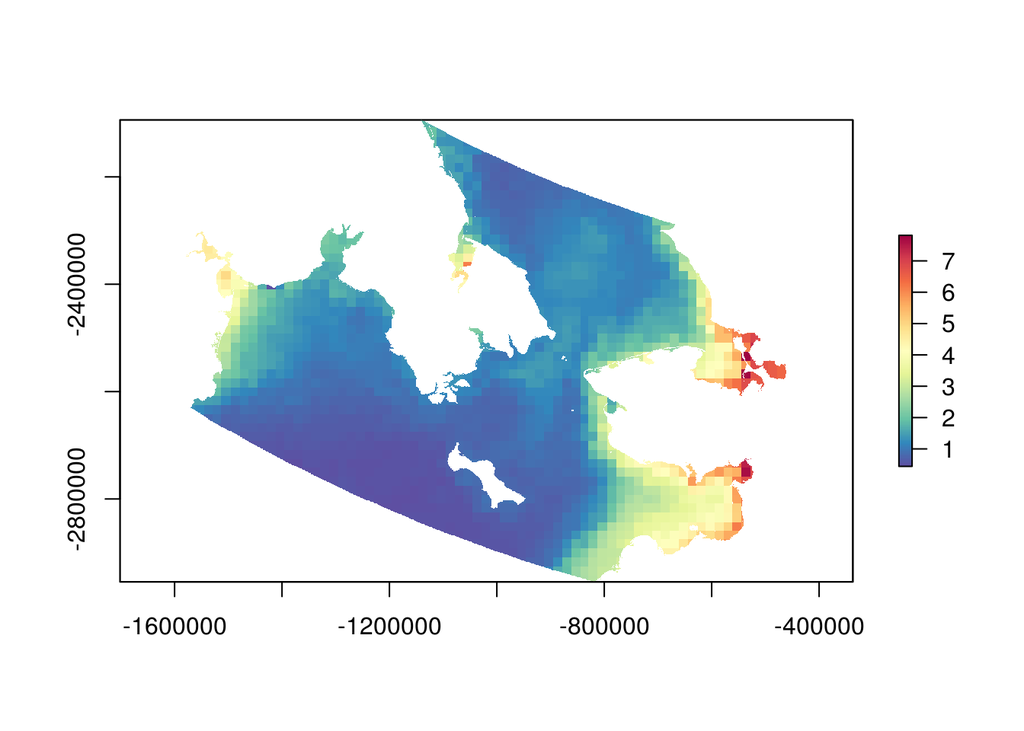

```r
  prod = raster('../productivity/output/five_yr_avg_09-13_bsr_laea.tif')

  plot(prod,col=cols)
```

Catch needs to be standardized by productivity

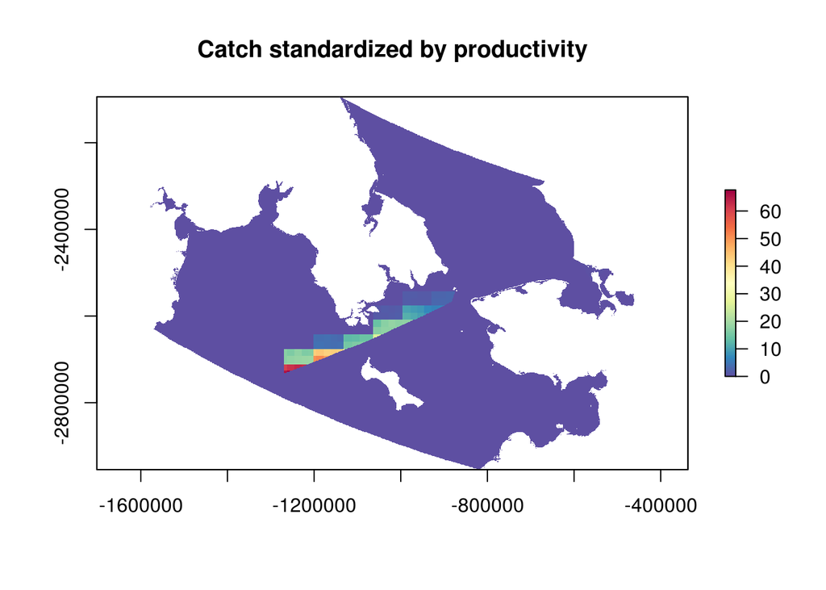

```r
  catch_prod = pel_lb_bsr/prod

  plot(catch_prod,col=cols, main = 'Catch standardized by productivity')
```

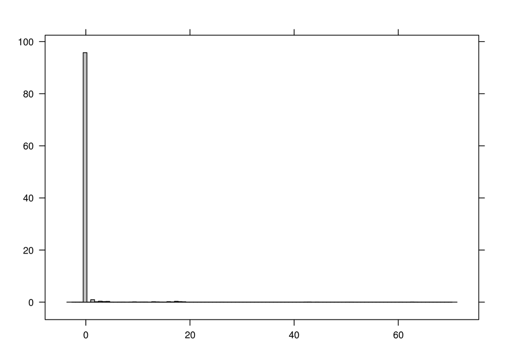

```r
  histogram(catch_prod)
```

***

Rescale

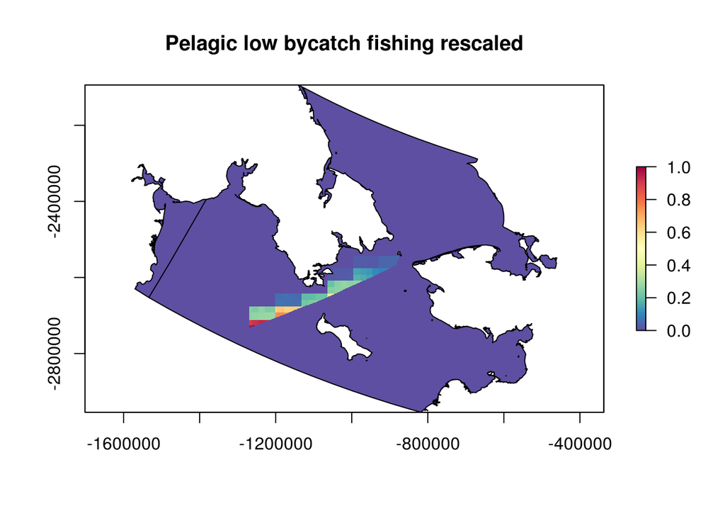

```r
max = cellStats(catch_prod,stat='max')

pel_lb_rescale_max = catch_prod/max


plot(pel_lb_rescale_max,col=cols,main='Pelagic low bycatch fishing rescaled')
plot(bsr,add=T)
```

```r
writeRaster(pel_lb_rescale_max,filename='output/pel_lb_bsr_catch_prod(5yravg).tif',overwrite=T)
```